# Outcrossing Populations

Check the final order:

```r
LG2_ord
```

```
#>
#> Best sequence found.
#> Printing map:
#>
#> Markers           Position           Parent 1       Parent 2
#>
#> 27 M27                0.00           b |  | o       a |  | a
#> 16 M16               11.76           a |  | a       b |  | o
#> 20 M20               22.94           a |  | b       c |  | d
#>  4 M4                35.71           a |  | o       o |  | b
#> 23 M23               53.69           a |  | o       a |  | o
#> 45 SNP17             72.86           a |  | b       a |  | a
#> 50 SNP23            103.35           a |  | b       b |  | a
#> 24 M24              108.37           a |  | b       b |  | a
#> 49 SNP22            112.25           a |  | b       b |  | a
#>
#> 9 markers            log-likelihood: -551.4083
#>
#>
#>
#> The following markers could not be uniquely positioned.
#> Printing most likely positions for each unpositioned marker:
#>
#> ------------------------------------------------------
#> |    |   9 |  21 |  29 |  46 |  47 |  48 |  51 |  52 |
#> |----|-----|-----|-----|-----|-----|-----|-----|-----|
#> |    |     |     |     |     |     |     |     |     |
#> | 27 |     |     |     |     |     |     |     |     |
#> |    |     |     |     |     |     |     |     |     |
#> | 16 |     |     |     |     |     |     |     |     |
#> |    |     |     |     |     |     |     |     |     |
#> | 20 |     |     |     |     |     |     |     |     |
#> |    |     |     |     |     |     |     |     |     |
#> |  4 |     |     |     |     |     |     |     |     |
#> |    |     | *** |     |     |     |     |     |     |
#> | 23 |     |     |     |     |     |     |     |     |
#> |    | *** | *   |     | *   |     | *** |     |     |
#> | 45 |     |     |     |     |     |     |     |     |
#> |    | *   |     | **  | *** | *** |     | *** |     |
#> | 50 |     |     |     |     |     |     |     |     |
#> |    |     |     |     |     |     |     |     |     |
#> | 24 |     |     |     |     |     |     |     |     |
#> |    |     |     |     |     |     |     |     |     |
#> | 49 |     |     |     |     |     |     |     |     |
#> |    |     |     | *** |     |     |     | **  | *** |
#> ------------------------------------------------------
#>
#> '***' indicates the most likely position(s) (LOD = 0.0)
#>
#> '**' indicates very likely positions (LOD > -1.0)
#>
#> '*' indicates likely positions (LOD > -2.0)
```

Note that markers `9`, `21`, `29`, `46`, `47`, `48`, `51` and `52` could not be safely mapped to a single position (`LOD Score > THRES` in absolute value). The output displays the `safe` order and the most likely positions for markers not mapped, where `***` indicates the most likely position and `*` corresponds to other plausible positions.

To get the safe order (*i.e.*, without markers `9`, `21`, `29`, `46`, `47`, `48`, `51` and `52`), use

```r
LG2_safe <- make_seq(LG2_ord, "safe")
```

and to get the order with all markers, use

```r
LG2_all <- make_seq(LG2_ord, "force")
LG2_all
```

```
#>
#> Printing map:
#>
#> Markers           Position           Parent 1       Parent 2
#>
#> 27 M27                0.00           b |  | o       a |  | a
#> 16 M16               11.76           a |  | a       b |  | o
#> 20 M20               22.94           a |  | b       c |  | d
#>  4 M4                35.71           a |  | o       o |  | b
#> 21 M21               49.40           o |  | o       a |  | b
#> 23 M23               55.18           a |  | o       a |  | o
#> 48 SNP21             67.73           a |  | b       a |  | a
#>  9 M9                74.32           a |  | b       a |  | a
#> 46 SNP18             80.85           a |  | b       a |  | a
#> 45 SNP17             96.14           a |  | b       a |  | a
#> 47 SNP20            121.33           a |  | b       a |  | a
#> 29 M29              170.70           o |  | a       o |  | o
#> 50 SNP23            192.38           a |  | b       b |  | a
#> 24 M24              197.52           a |  | b       b |  | a
#> 49 SNP22            200.80           a |  | b       b |  | a
#> 52 SNP25            205.70           a |  | b       b |  | a
#> 51 SNP24            216.64           a |  | b       b |  | a
#>
#> 17 markers            log-likelihood: -871.9124
```

Notice that, for this linkage group, the `forced` map obtained with `order_seq` is different from that obtained with `compare` plus `try_seq`. It depends on which markers we choose to try to add first when doing manually.

The `order_seq` function can also perform two rounds of the `try_seq` algorithms, first using `THRES` and then `THRES - 1` as a threshold. This generally results in safe orders with more markers mapped but may take longer to run. To do this, use the `touchdown` option:

```r
LG2_ord <- order_seq(LG2, n.init = 5, THRES = 3, touchdown = TRUE)
```

```r
LG2_ord
```

```
#>
#> Best sequence found.
#> Printing map:
#>
#> Markers           Position           Parent 1       Parent 2
#>
#> 27 M27                0.00           b |  | o       a |  | a
#> 16 M16               11.76           a |  | a       b |  | o
#> 20 M20               22.94           a |  | b       c |  | d
#>  4 M4                35.71           a |  | o       o |  | b
#> 23 M23               52.88           a |  | o       a |  | o
#> 48 SNP21             65.21           a |  | b       a |  | a
#> 45 SNP17             79.22           a |  | b       a |  | a
#> 47 SNP20            103.39           a |  | b       a |  | a
#> 50 SNP23            143.48           a |  | b       b |  | a
#> 24 M24              148.50           a |  | b       b |  | a
#> 49 SNP22            151.80           a |  | b       b |  | a
#> 52 SNP25            156.80           a |  | b       b |  | a
#>
#> 12 markers            log-likelihood: -670.5
#>
#>
#>
#> The following markers could not be uniquely positioned.
#> Printing most likely positions for each unpositioned marker:
#>
#> ------------------------------------
#> |    |   9 |  21 |  29 |  46 |  51 |
#> |----|-----|-----|-----|-----|-----|
#> |    |     |     |     |     |     |
#> | 27 |     |     |     |     |     |
#> |    |     |     |     |     |     |
#> | 16 |     |     |     |     |     |
#> |    |     |     |     |     |     |
#> | 20 |     |     |     |     |     |
#> |    |     |     |     |     |     |
#> |  4 |     |     |     |     |     |
#> |    |     | *** |     |     |     |
#> | 23 |     |     |     |     |     |
#> |    |     |     |     |     |     |
#> | 48 |     |     |     |     |     |
#> |    | *** |     |     | *** |     |
#> | 45 |     |     |     |     |     |
#> |    |     |     |     | *   |     |
#> | 47 |     |     |     |     |     |
#> |    |     |     | *** |     | **  |
#> | 50 |     |     |     |     |     |
#> |    |     |     |     |     |     |
#> | 24 |     |     |     |     |     |
#> |    |     |     |     |     |     |
#> | 49 |     |     |     |     |     |
#> |    |     |     |     |     |     |
#> | 52 |     |     |     |     |     |
#> |    |     |     | **  |     | *** |
#> ------------------------------------
#>
#> '***' indicates the most likely position(s) (LOD = 0.0)
#>
#> '**' indicates very likely positions (LOD > -1.0)
#>
#> '*' indicates likely positions (LOD > -2.0)
```

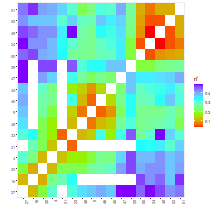

```r
rf_graph_table(LG2_all, mrk.axis = "numbers")
```

Finally, to check for alternative orders (because we did not use exhaustive search), use the `ripple_seq` function:

```r
ripple_seq(LG2_all, ws = 4, LOD = LOD_sug)
```

```
#> 27-16-20-4-|-21-... OK
#>
#> ...-27-|-16-20-4-21-|-23-... OK
#>
#> ...-16-|-20-4-21-23-|-48-...
#>   Alternative orders:
#>   ... 16 20 4 21 23 48 ... :    0.00 ( linkage phases: ... 1 2 2 1 1 ... )
#>   ... 16 20 4 23 21 48 ... :   -2.21 ( linkage phases: ... 1 2 2 1 1 ... )
#>
#> ...-20-|-4-21-23-48-|-9-...
#>   Alternative orders:
#>   ... 20 4 21 23 48 9 ... :    0.00 ( linkage phases: ... 2 2 1 1 1 ... )
#>   ... 20 4 23 21 48 9 ... :   -2.21 ( linkage phases: ... 2 2 1 1 1 ... )
#>
#> ...-4-|-21-23-48-9-|-46-...
#>   Alternative orders:
#>   ... 4 21 23 48 9 46 ... :    0.00 ( linkage phases: ... 2 1 1 1 1 ... )
#>   ... 4 23 21 48 9 46 ... :   -2.21 ( linkage phases: ... 2 1 1 1 1 ... )
#>
#> ...-21-|-23-48-9-46-|-45-...
#>   Alternative orders:
#>   ... 21 23 48 9 46 45 ... :    0.00 ( linkage phases: ... 1 1 1 1 1 ... )
#>   ... 21 23 48 46 9 45 ... :   -1.05 ( linkage phases: ... 1 1 1 1 1 ... )
#>
#> ...-23-|-48-9-46-45-|-47-...
#>   Alternative orders:
#>   ... 23 48 9 46 45 47 ... :    0.00 ( linkage phases: ... 1 1 1 1 1 ... )
#>   ... 23 48 46 9 45 47 ... :   -1.05 ( linkage phases: ... 1 1 1 1 1 ... )
#>   ... 23 48 45 9 46 47 ... :   -1.80 ( linkage phases: ... 1 1 1 1 1 ... )
#>   ... 23 48 9 45 46 47 ... :   -3.21 ( linkage phases: ... 1 1 1 1 1 ... )
#>   ... 23 45 48 9 46 47 ... :   -3.58 ( linkage phases: ... 1 1 1 1 1 ... )
#>
#> ...-48-|-9-46-45-47-|-29-...
#>   Alternative orders:
#>   ... 48 9 46 45 47 29 ... :    0.00 ( linkage phases: ... 1 1 1 1 3 ... )
#>   ... 48 46 9 45 47 29 ... :   -1.05 ( linkage phases: ... 1 1 1 1 3 ... )
#>   ... 48 45 9 46 47 29 ... :   -1.80 ( linkage phases: ... 1 1 1 1 3 ... )
#>   ... 48 9 45 46 47 29 ... :   -3.21 ( linkage phases: ... 1 1 1 1 3 ... )
#>
#> ...-9-|-46-45-47-29-|-50-...
```

[output cut: 11 more lines]

```
#>   Alternative orders:
#>   ... 29 50 24 49 52 51 :    0.00 ( linkage phases: ... 4 1 1 1 1 )
#>   ... 29 52 49 24 50 51 :   -0.90 ( linkage phases: ... 4 1 1 1 1 )
#>   ... 29 50 24 52 49 51 :   -2.76 ( linkage phases: ... 4 1 1 1 1 )
#>   ... 29 50 52 49 24 51 :   -2.79 ( linkage phases: ... 4 1 1 1 1 )
#>   ... 29 50 49 52 24 51 :   -3.31 ( linkage phases: ... 4 1 1 1 1 )
#>   ... 29 49 52 24 50 51 :   -3.31 ( linkage phases: ... 4 1 1 1 1 )
#>
#> 50-|-24-49-52-51
#>   Alternative orders:
#>   ... 50 24 49 52 51 :    0.00 ( linkage phases: ... 1 1 1 1 )
#>   ... 50 24 52 49 51 :   -2.76 ( linkage phases: ... 1 1 1 1 )
#>   ... 50 52 49 24 51 :   -2.79 ( linkage phases: ... 1 1 1 1 )
#>   ... 50 51 24 49 52 :   -2.85 ( linkage phases: ... 1 1 1 1 )
#>   ... 50 49 52 24 51 :   -3.31 ( linkage phases: ... 1 1 1 1 )
```

We should do this to any of the orders we found, either using `try_seq` or `order_seq`. Here, we choose `LG2_all` for didactic purposes only. The second argument, `ws = 4`, means that subsets (windows) of four markers will be permuted sequentially (`4!` orders for each window), to search for other plausible orders. The `LOD` argument means that only orders with LOD Score smaller than 3.68 will be printed.

The output shows sequences of four numbers, because `ws = 4`. They are followed by an `OK` if there is no alternative order with LOD Score smaller than `LOD = LOD_sug` in absolute value, or by a list of alternative orders. In the example, some sequences showed alternative orders with LOD smaller than `LOD = LOD_sug`. However, the best order was the original one (`LOD = 0.00`).

If there were an alternative order more likely than the original, one should check the difference between these orders (and linkage phases).

In some cases, even if there are no better alternative orders suggested by `ripple_seq`, the graphic showed a color pattern different from the expected. Then, we can remove doubtful markers (for this groups markers `23` and `29`) and try to position them again. First, we use the function `drop_marker` to remove the selected marker of our sequence.

```r
LG2_test_seq <- drop_marker(LG2_all, c(23,29))
```

The function will provide a sequence with the same order as the estimated map (`LG2_all`). After, we should estimate the map again using this predefined order (see section `Map estimation for an arbitrary order` for further information). For this we use the `map` function:

```r
(LG2_test_map <- map(LG2_test_seq))
```

**Warning**: If you find an error message like:

```
Error in as_mapper(.f, ...) : argument ".f" is missing, with no default
```

It’s because the `map` function has a very common name, and you can have in your environment other functions with the same name. In the case of the pointed error, R is using the `map` function from `purrr` package instead of `OneMap`, to solve this, simply specify that you want the `OneMap` function with `::` command from `stringr` package:

```r
library(stringr)
(LG2_test_map <- onemap::map(LG2_test_seq))
```

```
#>
#> Printing map:
#>
#> Markers           Position           Parent 1       Parent 2
#>
#> 27 M27                0.00           b |  | o       a |  | a
#> 16 M16               11.75           a |  | a       o |  | b
#> 20 M20               22.93           a |  | b       d |  | c
#>  4 M4                35.70           a |  | o       b |  | o
#> 21 M21               52.67           o |  | o       b |  | a
#> 48 SNP21             53.59           a |  | b       a |  | a
#>  9 M9                60.40           a |  | b       a |  | a
#> 46 SNP18             66.83           a |  | b       a |  | a
#> 45 SNP17             81.83           a |  | b       a |  | a
#> 47 SNP20            106.46           a |  | b       a |  | a
#> 50 SNP23            145.68           a |  | b       a |  | b
#> 24 M24              150.69           a |  | b       a |  | b
#> 49 SNP22            153.97           a |  | b       a |  | b
#> 52 SNP25            158.87           a |  | b       a |  | b
#> 51 SNP24            169.81           a |  | b       a |  | b
#>
#> 15 markers            log-likelihood: -780.5746
```

**NOTE**: (new!) If your sequence has many markers (more than 60), we suggest to speed up `map` using BatchMap parallelization approach. See section `Speed up analysis with parallelization` for more information.

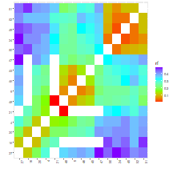

```r
rf_graph_table(LG2_test_map, mrk.axis = "numbers")
```

We use the `try_seq` function to positioned them again:

```r
LG2_test_seq <- try_seq(LG2_test_map, 23)
```

```
#> 23 --> M23   : ................
```

```r
LG2_test_23 <- make_seq(LG2_test_seq, 6)
LG2_test_seq <- try_seq(LG2_test_23, 29)
```

```
#> 29 --> M29   : .................
```

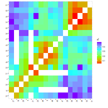

```r
LG2_test_23_29 <- make_seq(LG2_test_seq, 12)
rf_graph_table(LG2_test_23_29, mrk.axis = "numbers")
```

Marker `23` kept its previous position, but marker `29` was re-positioned, configuring now a gap between markers `47` and `50`. We removed marker `29` from our map because its color pattern is too different from expected. Then, our final map is:

```r
LG2_final <- LG2_test_23
LG2_final
```

```
#>
#> Printing map:
#>
#> Markers           Position           Parent 1       Parent 2
#>
#> 27 M27                0.00           b |  | o       a |  | a
#> 16 M16               11.75           a |  | a       o |  | b
#> 20 M20               22.93           a |  | b       d |  | c
#>  4 M4                35.70           a |  | o       b |  | o
#> 21 M21               50.34           o |  | o       b |  | a
#> 23 M23               54.87           a |  | o       o |  | a
#> 48 SNP21             70.11           a |  | b       a |  | a
#>  9 M9                76.77           a |  | b       a |  | a
#> 46 SNP18             83.19           a |  | b       a |  | a
#> 45 SNP17             98.20           a |  | b       a |  | a
#> 47 SNP20            122.83           a |  | b       a |  | a
#> 50 SNP23            161.89           a |  | b       a |  | b
#> 24 M24              166.89           a |  | b       a |  | b
#> 49 SNP22            170.18           a |  | b       a |  | b
#> 52 SNP25            175.08           a |  | b       a |  | b
#> 51 SNP24            186.02           a |  | b       a |  | b
#>
#> 16 markers            log-likelihood: -811.7886
```

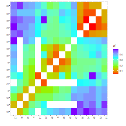

```r
rf_graph_table(LG2_final, mrk.axis = "numbers")
```

## Genetic mapping of linkage group 1

Finally, linkage group 1 (the largest one) will be analyzed. Extract markers:

```r
LG1 <- make_seq(LGs, 1)
```

Construct the linkage map, by automatically using the try algorithm:

```r
LG1_ord <- order_seq(LG1, n.init = 6, touchdown = TRUE)
```

Notice that the second round of `try_seq` added markers `10`, `31`, `32`, `35`, `36`, and `40`.

```r
LG1_ord
```

```
#>
#> Best sequence found.
#> Printing map:
#>
#> Markers           Position           Parent 1       Parent 2
#>
#> 34 SNP5               0.00           a |  | b       a |  | b
#> 32 SNP2              13.48           a |  | b       a |  | b
#> 12 M12               17.26           b |  | a       c |  | a
#> 31 SNP1              22.81           a |  | b       a |  | b
#>  3 M3                46.09           o |  | a       o |  | o
#> 14 M14               59.22           a |  | o       b |  | o
#>  2 M2                66.93           o |  | o       o |  | a
#> 36 SNP7              92.49           b |  | a       b |  | a
#> 35 SNP6             105.45           b |  | a       b |  | a
#>  1 M1               109.86           b |  | a       b |  | a
#> 10 M10              115.37           a |  | a       o |  | b
#> 28 M28              132.05           a |  | o       b |  | o
#> 26 M26              164.42           a |  | b       d |  | c
#> 42 SNP13            179.54           b |  | a       b |  | a
#>  6 M6               185.89           b |  | a       b |  | a
#> 39 SNP10            192.06           b |  | a       b |  | a
#> 41 SNP12            208.53           b |  | a       b |  | a
#> 40 SNP11            225.65           b |  | a       b |  | a
#> 15 M15              267.89           o |  | a       o |  | b
#>
#> 19 markers            log-likelihood: -1313.595
#>
#>
#>
#> The following markers could not be uniquely positioned.
#> Printing most likely positions for each unpositioned marker:
#>
#> ------------------------------------------
#> |    |   5 |  11 |  30 |  33 |  37 |  38 |
#> |----|-----|-----|-----|-----|-----|-----|
#> |    |     |     |     |     |     |     |
#> | 34 |     |     |     |     |     |     |
#> |    |     |     |     | *** |     |     |
#> | 32 |     |     |     |     |     |     |
```

[output cut: 27 more lines]

```
#> | 39 |     |     |     |     |     |     |
#> |    |     |     |     |     |     |     |
#> | 41 |     |     |     |     |     |     |
#> |    |     |     |     |     |     |     |
#> | 40 |     |     |     |     |     |     |
#> |    | **  | **  |     |     |     |     |
#> | 15 |     |     |     |     |     |     |
#> |    | *** | *** |     |     |     |     |
#> ------------------------------------------
#>
#> '***' indicates the most likely position(s) (LOD = 0.0)
#>
#> '**' indicates very likely positions (LOD > -1.0)
#>
#> '*' indicates likely positions (LOD > -2.0)
```

Now, get the order with all markers:

```r
(LG1_frame <- make_seq(LG1_ord, "force"))
```

```
#>
#> Printing map:
#>
#> Markers           Position           Parent 1       Parent 2
#>
#> 34 SNP5               0.00           a |  | b       a |  | b
#> 33 SNP3              12.27           a |  | b       a |  | b
#> 32 SNP2              18.45           a |  | b       a |  | b
#> 30 M30               21.21           a |  | b       a |  | b
#> 12 M12               22.22           b |  | a       c |  | a
#> 31 SNP1              27.77           a |  | b       a |  | b
#>  3 M3                51.05           o |  | a       o |  | o
#> 14 M14               64.18           a |  | o       b |  | o
#>  2 M2                72.05           o |  | o       o |  | a
#> 36 SNP7              95.86           b |  | a       b |  | a
```

[output cut: 17 more lines]

Check the map graphically:

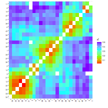

```r
rf_graph_table(LG1_frame, mrk.axis = "numbers")
```

Check for alternative orders:

```r
ripple_seq(LG1_frame)
```

```
#> 34-33-32-30-|-12-...
#>   Alternative orders:
#>    34 33 32 30 12 ... :    0.00 ( linkage phases: 1 1 1 4 ... )
#>    34 32 33 30 12 ... :   -1.29 ( linkage phases: 1 1 1 4 ... )
#>    34 33 30 32 12 ... :   -1.55 ( linkage phases: 1 1 1 4 ... )
#>
#> ...-34-|-33-32-30-12-|-31-...
#>   Alternative orders:
#>    34 33 12 30 32 31 ... :    0.00 ( linkage phases:  1 4 4 1 1 ... )
#>    34 33 30 12 32 31 ... :   -0.25 ( linkage phases:  1 1 4 4 1 ... )
#>    34 33 32 30 12 31 ... :   -0.59 ( linkage phases:  1 1 1 4 4 ... )
#>    34 32 33 30 12 31 ... :   -1.88 ( linkage phases:  1 1 1 4 4 ... )
#>    34 33 30 32 12 31 ... :   -2.14 ( linkage phases:  1 1 1 4 4 ... )
#>    34 33 32 12 30 31 ... :   -2.74 ( linkage phases:  1 1 4 4 1 ... )
#>
#> ...-33-|-32-30-12-31-|-3-...
#>   Alternative orders:
#>   ... 33 12 30 32 31 3 ... :    0.00 ( linkage phases: ... 4 4 1 1 4 ... )
#>   ... 33 30 12 32 31 3 ... :   -0.25 ( linkage phases: ... 1 4 4 1 4 ... )
#>   ... 33 32 30 12 31 3 ... :   -0.59 ( linkage phases: ... 1 1 4 4 4 ... )
#>   ... 33 30 32 12 31 3 ... :   -2.14 ( linkage phases: ... 1 1 4 4 4 ... )
#>   ... 33 32 12 30 31 3 ... :   -2.74 ( linkage phases: ... 1 4 4 1 4 ... )
#>
#> ...-32-|-30-12-31-3-|-14-...
#>   Alternative orders:
#>   ... 32 30 12 31 3 14 ... :    0.00 ( linkage phases: ... 1 4 4 4 4 ... )
#>   ... 32 12 30 31 3 14 ... :   -2.15 ( linkage phases: ... 4 4 1 4 4 ... )
#>
#> ...-30-|-12-31-3-14-|-2-... OK
#>
#> ...-12-|-31-3-14-2-|-36-... OK
#>
#> ...-31-|-3-14-2-36-|-37-... OK
#>
#> ...-3-|-14-2-36-37-|-35-...
#>   Alternative orders:
#>   ... 3 14 2 36 37 35 ... :    0.00 ( linkage phases: ... 4 2 3 1 1 ... )
#>   ... 3 14 2 37 36 35 ... :   -0.89 ( linkage phases: ... 4 2 3 1 1 ... )
#>
#> ...-14-|-2-36-37-35-|-1-...
```

[output cut: 58 more lines]

```
#> ...-42-|-6-39-41-40-|-15-... OK
#>
#> ...-6-|-39-41-40-15-|-5-... OK
#>
#> ...-39-|-41-40-15-5-|-11-...
#>   Alternative orders:
#>   ... 39 41 40 15 5 11 :    0.00 ( linkage phases: ... 1 1 1 1 1 )
#>   ... 39 41 40 5 15 11 :   -2.57 ( linkage phases: ... 1 1 1 1 1 )
#>
#> 41-|-40-15-5-11
#>   Alternative orders:
#>   ... 41 40 15 5 11 :    0.00 ( linkage phases: ... 1 1 1 1 )
#>   ... 41 40 11 5 15 :   -0.82 ( linkage phases: ... 1 1 1 1 )
#>   ... 41 40 5 15 11 :   -2.57 ( linkage phases: ... 1 1 1 1 )
#>   ... 41 40 11 15 5 :   -2.58 ( linkage phases: ... 1 1 1 1 )
```

Let’s check how it behaves with the MDS approach:

```r
LG1_mds <- mds_onemap(LG1, rm_unlinked = TRUE, hmm = F)
```

```
#> Stress: 0.0977824625051689
#> Mean Nearest Neighbour Fit: 173.162258470925
```

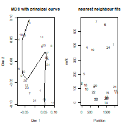

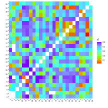

```r
rf_graph_table(LG1_mds)
```

Based on the drafts from `order_seq` or/and `mds_onemap`, we can remove some doubtful markers accordingly with the graphic, try to position them again, and decide if and where we will maintain them.

```r
LG1_test_seq <- drop_marker(LG1_frame, c(10,11,28,42))
LG1_test_map <- onemap::map(LG1_test_seq)
```

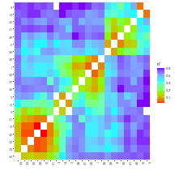

```r
rf_graph_table(LG1_test_map, mrk.axis = "numbers")
```

```r
LG1_extend <- try_seq(LG1_test_map,10)
LG1_test_map <- make_seq(LG1_extend,15)
LG1_extend <- try_seq(LG1_test_map,11)
LG1_test <- make_seq(LG1_extend,23) # We choose to remove this marker
LG1_extend <- try_seq(LG1_test_map,28)
LG1_test_map <- make_seq(LG1_extend,16)
LG1_extend <- try_seq(LG1_test_map,42)
LG1_final <- make_seq(LG1_extend,17)
```

Print it:

```r
LG1_final
```

```
#>
#> Printing map:
#>
#> Markers           Position           Parent 1       Parent 2
#>
#> 34 SNP5               0.00           a |  | b       a |  | b
#> 33 SNP3              12.27           a |  | b       a |  | b
#> 32 SNP2              18.45           a |  | b       a |  | b
#> 30 M30               21.21           a |  | b       a |  | b
#> 12 M12               22.22           b |  | a       c |  | a
#> 31 SNP1              27.77           a |  | b       a |  | b
#>  3 M3                51.05           o |  | a       o |  | o
#> 14 M14               64.18           a |  | o       b |  | o
#>  2 M2                72.10           o |  | o       o |  | a
#> 36 SNP7              95.93           b |  | a       b |  | a
```

[output cut: 16 more lines]

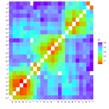

```r
rf_graph_table(LG1_final)
```

As an option, different algorithms to order markers could be applied:

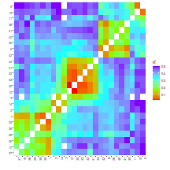

```r
LG1_ser <- seriation(LG1, hmm = F)
rf_graph_table(LG1_ser)
```

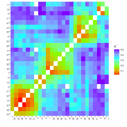

```r
LG1_rcd <- rcd(LG1, hmm = F)
rf_graph_table(LG1_rcd)
```

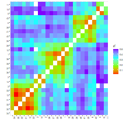

```r
LG1_rec <- record(LG1, hmm = F)
rf_graph_table(LG1_rec)
```

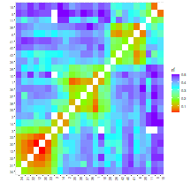

```r
LG1_ug  <- ug(LG1, hmm = F)
rf_graph_table(LG1_ug)
```

There are some differences between the results. Seriation did not provide good results in this case. See Mollinari et al. (2009) for an evaluation of these methods.

# Using the recombinations and the reference genome information

In our example, we have reference genome chromosome and position information for some of the markers; here, we will exemplify one method of using this information to help build the genetic map.

With the `CHROM` information in the input file, you can identify markers belonging to some chromosome using the function `make_seq` with the `rf_2pts` object. For example, assign the string `"1"` for the second argument to get chromosome 1 makers. The output sequence will be automatically ordered by `POS` information.

```r
CHR1 <- make_seq(twopts, "1")
CHR1
```

```
#>
#> Number of markers: 12
#> Markers in the sequence:
#> SNP1 SNP2 SNP3 SNP5 SNP6 SNP7 SNP8 SNP9 SNP10 SNP11 SNP12 SNP13
#>
#> Parameters not estimated.
```

```r
CHR2 <- make_seq(twopts, "2")
CHR3 <- make_seq(twopts, "3")
```

Here we use the string `"1"` because it is our chromosome ID, you can have a different string as ID, check this with:

```r
unique(bins_example$CHROM)
```

```
#> [1] NA  "1" "2" "3"
```

We can see that we have markers without chromosome information (`NA`) and markers with chromosome ID `"1"`, `"2"` and `"3"`.

## Adding markers with no reference genome information

According to `CHROM` information we have three defined linkage groups, now we can try to group the markers without chromosome information to them using recombination information. For this, we can use the function `group_seq`:

```r
CHR_mks <- group_seq(input.2pts = twopts, seqs = "CHROM", unlink.mks = mark_no_dist,
                     repeated = FALSE)
```

```
#>    Selecting markers:
#>    group    1
#>     ........................
#>    group    2
#>     ........
#>    group    3
#>     ....
#>    Selecting markers:
#>    group    1
#>     ......
#>    group    2
#>     ............
#>    group    3
#>     ........
#>    Selecting markers:
#>    group    1
#>     ................
#>    group    2
#>     ............
#>    group    3
#>     ....
```

The function works as the function `group` but considering pre-existing sequences. Setting `seqs` argument with the string `"CHROM"`, it will consider the pre-existing sequences according to `CHROM` information. You can also indicate other pre-existing sequences if they make sense for your study. For that, you should inform a list of objects of class `sequences`, as the example:

```r
CHR_mks <- group_seq(input.2pts = twopts, seqs = list(CHR1=CHR1, CHR2=CHR2, CHR3=CHR3),
                     unlink.mks = mark_no_dist, repeated = FALSE)
```

In this case, the command had the same effect as the previous because we indicate chromosome sequences, but other sequences can be used.

The `unlink.mks` argument receives an object of class `sequence`; this defines which markers will be tested to group with the sequences in `seqs`. In our example, we will indicate only the markers with no segregation distortion, using the sequence `mark_no_dist`. It is also possible to use the string `"all"` to test all the remaining markers at the `rf_2pts` object.

In some cases, the same marker can group into more than one sequence; those markers will be considered `repeated`. We can choose if we want to remove or not (`FALSE/TRUE`) them of the output sequences, with the argument `repeated`. Anyway, their numbers will be informed at the list `repeated` in the output object. In the example case, there are no repeated markers. However, if they exist, it could indicate that their groups actually constitute the same group. Also, genotyping errors can generate repeated markers. Anyway, they deserve better investigations.

We can access detailed information about the results, just printing:

```r
CHR_mks
```

```
#>   This is an object of class 'group_seq'
#>   Criteria used to assign markers to groups:
#>     LOD = 3 , Maximum recombination fraction = 0.5
#>
#>   No. markers in input sequences:
#>                        CHR1 :   12 markers
#>                        CHR2 :   2 markers
#>                        CHR3 :   8 markers
#>
#>   No. unlinked input markers:   27 markers
#>
#>   No. markers in output sequences:
#>                        CHR1 :   25 markers
#>                        CHR2 :   7 markers
#>                        CHR3 :   17 markers
#>   No. unlinked:                 0 markers
#>   No. repeated:                 0 markers
#>
#>   Printing output sequences:
#>   Group CHR1 : 25 markers
#>     SNP1 SNP2 SNP3 SNP5 SNP6 SNP7 SNP8 SNP9 SNP10 SNP11 SNP12 SNP13 M1 M2 M3 M5 M6 M10 M11 M12 M14 M15 M26 M28 M30
#>
#>   Group CHR2 : 7 markers
#>     SNP14 SNP16 M7 M8 M13 M18 M22
#>
#>   Group CHR3 : 17 markers
#>     SNP17 SNP18 SNP20 SNP21 SNP22 SNP23 SNP24 SNP25 M4 M9 M16 M20 M21 M23 M24 M27 M29
#>
#>   Unlinked markers: 0 markers
#>
#>
#>   Repeated markers: 0  markers
#>
```

Also, we can access the numbers of repeated markers with:

```r
CHR_mks$repeated
```

```
#> [1] NA
```

We have no repeated markers.

In the same way, we can access the output sequences:

```r
CHR_mks$sequences$CHR1
```

```
#>
#> Number of markers: 25
#> Markers in the sequence:
#> SNP1 SNP2 SNP3 SNP5 SNP6 SNP7 SNP8 SNP9 SNP10 SNP11 SNP12 SNP13 M1 M2 M3 M5 M6
#> M10 M11 M12 M14 M15 M26 M28 M30
#>
#> Parameters not estimated.
```

```r
# or
CHR_mks$sequences[[1]]
```

```
#>
#> Number of markers: 25
#> Markers in the sequence:
#> SNP1 SNP2 SNP3 SNP5 SNP6 SNP7 SNP8 SNP9 SNP10 SNP11 SNP12 SNP13 M1 M2 M3 M5 M6
#> M10 M11 M12 M14 M15 M26 M28 M30
#>
#> Parameters not estimated.
```

For this function, optional arguments are `LOD` and `max.rf`, which define thresholds to be used when assigning markers to linkage groups. If none is provided (default), criteria previously defined for the object `rf_2pts` are used.

Now we can order the markers in each group as we made before in (Genetic mapping of linkage group 1,2 and 3). As shown, we can choose different approaches to order the markers.

To order those groups, first, we will use the `order_seq` function to access a preliminary order, and after, we will edit some marker’s positions or remove some of them according to their color pattern in the `rf_graph_table` graphic, and other parameters as likelihood and map size.